# 00_michelle_alfaro

<h1 id="00-%C2%B7-Gu%C3%ADa-r%C3%A1pida-de-JupyterLab">00 · Guía rápida de JupyterLab</h1><p>Material de apoyo para la clase. Cubre lo mínimo necesario para trabajar con el resto de los cuadernillos.</p> <hr /> <h2 id="1.-%C2%BFQu%C3%A9-es-un-notebook?">1. ¿Qué es un *notebook*?</h2><p>Es un documento interactivo que mezcla:</p>

- **Celdas de código** (Python) — se ejecutan con `Shift + Enter`.
- **Celdas de Markdown** — texto con formato (títulos, ecuaciones LaTeX, imágenes, enlaces).

<p>El estado (variables, figuras, imports) se conserva entre celdas mientras el kernel esté vivo.</p>

| `Shift + Enter` | Ejecutar celda y pasar a la siguiente |
| --- | --- |
| `Ctrl + Enter` | Ejecutar celda y quedarse |
| `A` / `B` | Insertar celda arriba / abajo |
| `M` / `Y` | Convertir a Markdown / Código |
| `D D` | Borrar celda |
| `Z` | Deshacer borrado |

<p>Probá ejecutar la siguiente celda:</p>

```python
import sys
from pathlib import Path
_src = Path.cwd().parent / "src"
if _src.exists() and str(_src) not in sys.path:
    sys.path.insert(0, str(_src))
```

```python
mensaje = "¡Hola desde JupyterLab!"
print(mensaje)
```

```
¡Hola desde JupyterLab!
```

<h2 id="3.-Markdown-+-LaTeX">3. Markdown + LaTeX</h2><p>Las celdas Markdown aceptan sintaxis estándar y ecuaciones en LaTeX entre `$$ ... $$`:</p> <p>$$ \Delta U = q + w \qquad \Delta H = \Delta U + \Delta (PV) $$</p> <p>Útil para escribir la ecuación de Clausius-Clapeyron, la definición de entropía, etc.</p>

<h2 id="4.-Comandos-magic-y-shell">4. Comandos *magic* y shell</h2><p>Los *magics* son instrucciones especiales de Jupyter. Las más usadas:</p>

- `%time` mide el tiempo de una línea.
- `%matplotlib inline` muestra las figuras de Matplotlib dentro del notebook.
- `!` ejecuta un comando de shell (por ejemplo `!pip install ...`).

```python
%matplotlib inline
%config InlineBackend.figure_format = "retina"  # figuras más nítidas

import numpy as np
import matplotlib.pyplot as plt
```

```
Matplotlib is building the font cache; this may take a moment.
```

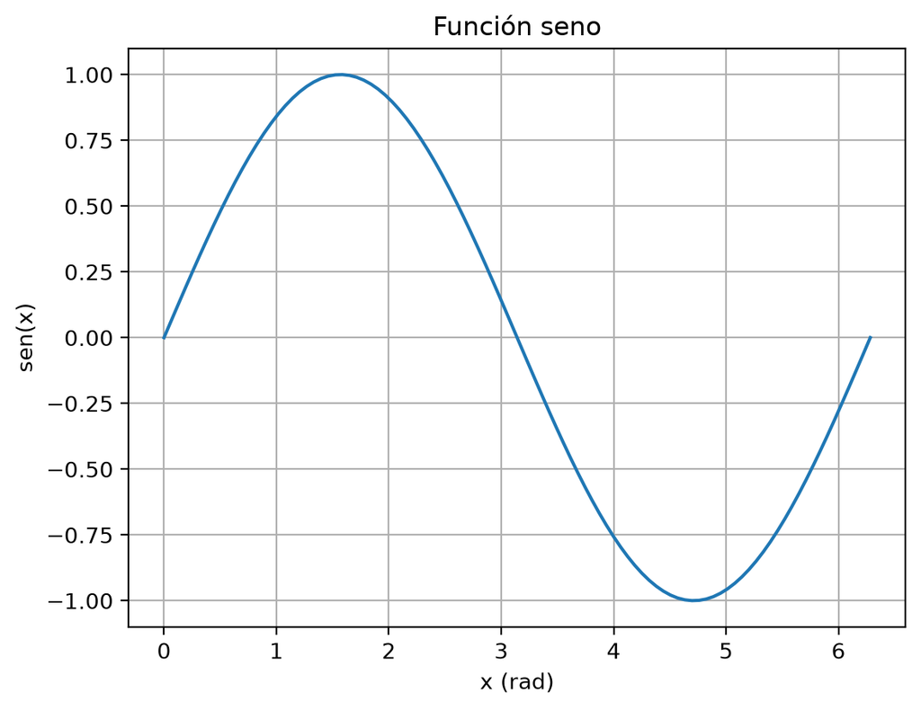

```python
x = np.linspace(0, 2 * np.pi, 100)
plt.plot(x, np.sin(x))
plt.title("Función seno")
plt.xlabel("x (rad)")
plt.ylabel("sen(x)")
plt.grid(True)
plt.show()
```

<h2 id="5.-Importar-los-m%C3%B3dulos-del-proyecto">5. Importar los módulos del proyecto</h2><p>Este repositorio tiene dos paquetes instalados en modo editable (`pip install -e .`):</p>

- `termodinamica` — las 3 leyes, Clausius-Clapeyron, Maxwell.
- `utils` — constantes físicas y solvers de EDO.

<p>Después de correr `make setup`, los siguientes imports funcionan en cualquier celda:</p>

```python
from utils.constantes import R
from termodinamica.primera_ley import energia_interna_gas_ideal

print(f"R = {R:.6f} J/(mol·K)")
print(f"ΔU (2 mol, Cv=12.5, ΔT=10 K) = {energia_interna_gas_ideal(2, 12.5, 300, 310):.1f} J")
```

```
R = 8.314463 J/(mol·K)
ΔU (2 mol, Cv=12.5, ΔT=10 K) = 250.0 J
```

```python
# Permite instalar las dependencias del proyecto
! pip install -r ../requirements.txt
```

[output not shown]

<h1 id="Ecuacion-para-la-tarea">Ecuacion para la tarea</h1><h2 id="Michelle-Alfaro-Alfaro">Michelle Alfaro Alfaro</h2><p>$$ PV = nRT $$</p>

```python
#Ejemplo de codigo
from utils.constantes import R
from termodinamica.primera_ley import energia_interna_gas_ideal

print("valor de R=",  R)
print("Valor de energia interna=",  energia_interna_gas_ideal(1.0, 12.5, 300, 310))
```

```
valor de R= 8.314462618
Valor de energia interna= 125.0
```

```python
#Ecuacion de ejemplo
from termodinamica.primera_ley import entalpia_gas_ideal
def entalpia_gas_ideal(n, Cp, T1, T2):
# Calcula el cambio de entalpía para un gas ideal.
# ΔH = n * Cp * ΔT
    return n * Cp * (T2 - T1)
print("Valor de entalpía =", entalpia_gas_ideal(1.0, 29.1, 300, 310));
```

```
Valor de entalpía = 291.0
```

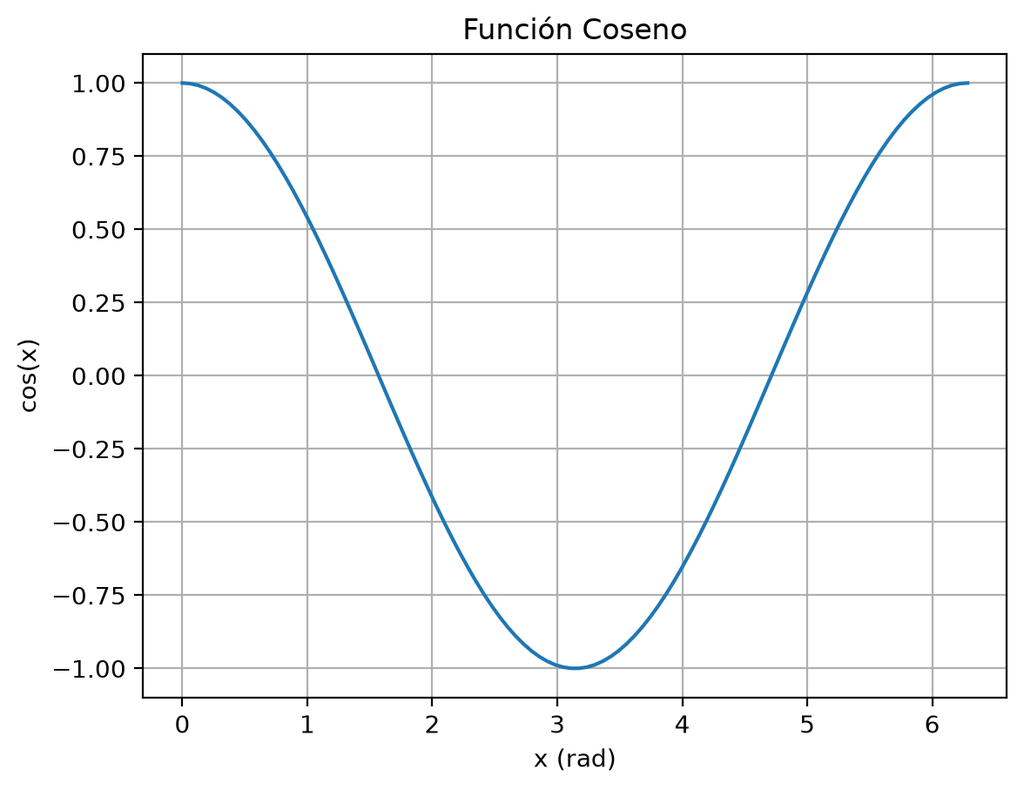

```python
# Grafico de coseno
%matplotlib inline
%config InlineBackend.figure_format = "retina"  # figuras más nítidas

import numpy as np
import matplotlib.pyplot as plt
x = np.linspace(0, 2 * np.pi, 100)
plt.plot(x, np.cos(x))
plt.title("Función Coseno")
plt.xlabel("x (rad)")
plt.ylabel("cos(x)")
plt.grid(True)
plt.show()
```